# Filling in Census Gaps: Geographical and Discrepancy Depictions for LA Housing/Census Project

David Haley, Jonni Johnson, and Lydia Palma

Here we describe the initial steps taken to identify discrepant areas between the American Community Survey (Census) and the LUPAMS/HCID-LA data sets. We were interested in geographically mapping areas of discrepancies in LA county for multiple family units among the data sets. Indicators associated with these discrepancies are also discussed.

# Analysis of LA Rental Housing

Load Data

```r
#install.packages("rgdal") #-- install packages as needed
#install.packages("ggmap")
#install.packages("maptools")
#install.packages("rgeos")
library(rgdal)    # for readOGR
library(ggplot2)
library(ggmap)
library(rgeos)
library(GGally)
CensusData = read.csv("Palm-LosAngelesRentalCensus.csv")
FullROIData = read.csv("ROI_12.15.14.csv")
```

#### Take a peek at both data sets

```r
head(CensusData)
```

```
##        GEOID ACS_MFRENTALS ACS_Owners ACS_SF_Rents LUPAMS HCIDLA LUPAMS_RC
## 1 6037101110           385        764          473    555    551         0
## 2 6037101122             0       1025          193     45     44         0
## 3 6037101210          1705        345          249   1725   1723         0
## 4 6037101220           499        427          238    668    667         0
## 5 6037101300            28       1318          189     52     51         0
## 6 6037101400           299        972          227    222    221         0
##   HCIDLA_RC
## 1        NA
## 2        NA
## 3        NA
## 4        NA
## 5        NA
## 6        NA
```

```r
head(FullROIData)
```

```
##   cntyfips cntyname      GEOID ruca density pop_flag population pct_un18
## 1        1  Alameda 6001400100    1      HD        0       2937    14.54
## 2        1  Alameda 6001400200    1      HD        0       1974    16.97
## 3        1  Alameda 6001400300    1      HD        0       4865    15.62
## 4        1  Alameda 6001400400    1      HD        0       3703    15.45
## 5        1  Alameda 6001400500    1      HD        0       3517    12.79
## 6        1  Alameda 6001400600    1      HD        0       1571    14.26
##   pct_ov65 pct_hisp pct_asian pct_black pct_white econdep roi_people
## 1    21.59     3.98     15.87      4.77     70.75       6      82.91
## 2    16.36     7.65       7.5      1.57     78.32       6      82.04
## 3    10.13      8.2      8.88     10.52     66.93       6      70.94
## 4     9.53     8.97      7.59      12.1     65.46       6      70.15
## 5     8.93     9.67      6.48     26.53     50.55       6      67.33
## 6     9.17     8.02      5.35     39.15     42.71       6      64.26
##   edppl_mean edppl1 edppl2 edppl3 edppl4 ecppl_mean ecppl1 ecppl2
```

[output cut: 125 more lines]

```r
str(CensusData)
```

```
## 'data.frame':    1000 obs. of  8 variables:
##  $ GEOID        : num  6.04e+09 6.04e+09 6.04e+09 6.04e+09 6.04e+09 ...
##  $ ACS_MFRENTALS: int  385 0 1705 499 28 299 141 65 188 164 ...
##  $ ACS_Owners   : int  764 1025 345 427 1318 972 468 1018 268 905 ...
##  $ ACS_SF_Rents : int  473 193 249 238 189 227 71 211 114 189 ...
##  $ LUPAMS       : int  555 45 1725 668 52 222 103 0 141 182 ...
##  $ HCIDLA       : int  551 44 1723 667 51 221 103 0 140 182 ...
##  $ LUPAMS_RC    : int  0 0 0 0 0 0 0 0 0 0 ...
##  $ HCIDLA_RC    : int  NA NA NA NA NA NA NA NA NA NA ...
```

Notice that the CensusData is incomplete – only 1000 data points! This must be a subset of the original data.

For this reason, we need to create a subset of ROIData to only include the same 1000 GEOID’s as CensusData. The census data has 8 variables for the 1000 GEOID’s where the ROI data has 137 variables for the 1000 GEOID’s.

```r
ROIData = FullROIData[FullROIData$GEOID %in% CensusData$GEOID,]
head(ROIData)
```

```
##      cntyfips    cntyname      GEOID ruca density pop_flag population
## 1172       37 Los Angeles 6037101110    1      HD        0       4731
## 1173       37 Los Angeles 6037101122    1      HD        0       3664
## 1174       37 Los Angeles 6037101210    1      HD        0       5990
## 1175       37 Los Angeles 6037101220    1      HD        0       3363
## 1176       37 Los Angeles 6037101300    1      HD        0       4199
## 1177       37 Los Angeles 6037101400    1      HD        0       3903
##      pct_un18 pct_ov65 pct_hisp pct_asian pct_black pct_white econdep
## 1172    19.68    10.15    27.99     10.65      1.56     56.14       5
## 1173    17.63    13.43    15.69     13.65      0.71     66.51       5
## 1174    22.97     8.46    37.05      7.63      3.06     48.25       5
## 1175    22.48    11.63    37.82      8.47      1.07     49.42       5
## 1176    16.77    17.91    11.98      7.74      0.98     75.97       5
## 1177    17.47     14.4    18.47      8.81      1.15     67.87       5
##      roi_people edppl_mean edppl1 edppl2 edppl3 edppl4 ecppl_mean ecppl1
```

[output cut: 132 more lines]

# Data Set Structure

Look at structure in order to get an intuition for the nature of this data

```r
str(CensusData)
```

```
## 'data.frame':    1000 obs. of  8 variables:
##  $ GEOID        : num  6.04e+09 6.04e+09 6.04e+09 6.04e+09 6.04e+09 ...
##  $ ACS_MFRENTALS: int  385 0 1705 499 28 299 141 65 188 164 ...
##  $ ACS_Owners   : int  764 1025 345 427 1318 972 468 1018 268 905 ...
##  $ ACS_SF_Rents : int  473 193 249 238 189 227 71 211 114 189 ...
##  $ LUPAMS       : int  555 45 1725 668 52 222 103 0 141 182 ...
##  $ HCIDLA       : int  551 44 1723 667 51 221 103 0 140 182 ...
##  $ LUPAMS_RC    : int  0 0 0 0 0 0 0 0 0 0 ...
##  $ HCIDLA_RC    : int  NA NA NA NA NA NA NA NA NA NA ...
```

Here is a copy of the dictionary supplied: 1. GEOID + Census tract identification number

2. ACS_MFRENTALS
- The number of rentals in multi-family units in a given tract, from the 2015 5 year wave ACS Data Table B20532
3. ACS_Owners
- The Number of owner occupied units of all types, from the 2015 5 year wave ACS Data Table B20532
4. ACS_SF_Rents
- The number of rentals in single family and single-family attached units in a given tract, from the 2015 5 year wave ACS Data Table B20532
5. LUPAMS
- Data from the LUPAMS office on the number of multi-family rentals registered on site (as required by the City’s proactive rental inspection program).
6. HCIDLA
- Data from the HCIDLA office on the number of multi-family rentals registered on site.
7. Data Sets
- LUPAMS_RC
  - Data from the LUPAMS office on the number of rent-controlled multi-family rentals registered on site (as required by the City’s proactive rental inspection program).
- HCIDLA_RC
  - Data from the HCIDLA office on the number of rent-controlled multi-family rentals registered on site.

```r
#the ROIData includes some apparently county wide statistics
ROIData[ROIData$population == "<Null>",]
```

```
##      cntyfips    cntyname      GEOID   ruca density pop_flag population
## 1474       37 Los Angeles 6037137000 <Null>  <Null>        0     <Null>
##      pct_un18 pct_ov65 pct_hisp pct_asian pct_black pct_white econdep
## 1474   <Null>   <Null>   <Null>    <Null>    <Null>    <Null>       5
##      roi_people edppl_mean edppl1 edppl2 edppl3 edppl4 ecppl_mean ecppl1
## 1474     <Null>     <Null>  60.25 <Null> <Null> <Null>      84.96  92.89
##      ecppl2 hsppl_mean hsppl1 hsppl2 moppl_mean moppl1 moppl2 moppl3
## 1474  88.18      59.49  84.85  45.87      52.79  96.04  42.16 <Null>
##      enppl_mean enppl1 enppl2 enppl3 soppl_mean soppl1 soppl3 roi_place
## 1474     <Null> <Null> <Null> <Null>      97.68 <Null>  98.26    <Null>
##      edplc_mean edplc1 edplc2 edplc3 edplc4 ecplc_mean ecplc1 ecplc2
## 1474     <Null> <Null> <Null> <Null> <Null>     <Null> <Null> <Null>
##      ecplc3 ecplc4 ecplc5 hsplc_mean hsplc1 hsplc2 enplc_mean enplc1
## 1474 <Null> <Null> <Null>      51.13   99.6   0.14     <Null> <Null>
##      enplc2 enplc3 enplc4 soplc_mean soplc1 soplc2 z_roi_people
## 1474 <Null> <Null> <Null>      91.96  92.89  92.84       <Null>
##      z_edppl_mean z_edppl1 z_edppl2 z_edppl3 z_edppl4 z_ecppl_mean
## 1474       <Null>     1.11   <Null>   <Null>   <Null>         1.09
##      z_ecppl1 z_ecppl2 z_hsppl_mean z_hsppl1 z_hsppl2 z_moppl_me z_moppl1
## 1474     0.66     1.16         0.49      1.2    -0.42      -1.54     0.82
##      z_moppl2 z_moppl3 z_enppl_mean z_enppl1 z_enppl2 z_enppl3
## 1474    -1.38   <Null>       <Null>   <Null>   <Null>   <Null>
##      z_soppl_mean z_soppl1 z_soppl2 z_roi_place z_edplc_mean z_edplc1
## 1474         2.57   <Null>     0.83      <Null>       <Null>   <Null>
##      z_edplc2 z_edplc3 z_edplc4 z_ecplc_mean z_ecplc1 z_ecplc2 z_ecplc3
## 1474   <Null>   <Null>   <Null>       <Null>   <Null>   <Null>   <Null>
##      z_ecplc4 z_ecplc5 z_hsplc_mean z_hsplc1 z_hsplc2 z_enplc_mean
## 1474   <Null>   <Null>        -0.44     0.86    -0.55       <Null>
##      z_enplc1 z_enplc2 z_enplc3 z_enplc4 z_soplc_mean z_soplc1 z_soplc2
## 1474   <Null>   <Null>   <Null>   <Null>         1.08     0.75     0.98
##      rflag_edppl1 rflag_ecppl1 rflag_ecppl2 rflag_ecppl1.1 rflag_ecppl2.1
## 1474            0            0            0              0              0
##      rflag_moppl1 rflag_moppl2 rflag_enppl1 rflag_enppl2 rflag_soppl1
## 1474            0            0            0            0            1
##      rflag_soppl2 rflag_ecplc1 rflag_ecplc2 rflag_ecplc3 rflag_ecplc5
## 1474            0            0            0            0            0
##      rflag_hsplc1 rflag_hsplc2 rflag_enplc1 rflag_soplc1 rflag_soplc2
## 1474            0            0            0            0            0
##      edppl_flag ecppl_flag hsppl_flag moppl_flag enppl_flag soppl_flag
## 1474          0          0          0          1          0          1
##      edplc_flag ecplc_flag hsplc_flag enplc_flag soplc_flag
## 1474          0          0          0          0          0
```

```r
ROIData[ROIData$population == 0,]
```

```
##      cntyfips    cntyname      GEOID ruca density pop_flag population
## 3505       37 Los Angeles 6037980020   10      LD        1          0
##      pct_un18 pct_ov65 pct_hisp pct_asian pct_black pct_white econdep
## 3505   #NULL!   #NULL!   #NULL!    #NULL!    #NULL!    #NULL!       5
##      roi_people edppl_mean edppl1 edppl2 edppl3 edppl4 ecppl_mean ecppl1
## 3505     <Null>      71.63 <Null>  77.22  73.78  17.35     <Null> <Null>
##      ecppl2 hsppl_mean hsppl1 hsppl2 moppl_mean moppl1 moppl2 moppl3
## 3505 <Null>     <Null> <Null> <Null>     <Null> <Null> <Null>      0
##      enppl_mean enppl1 enppl2 enppl3 soppl_mean soppl1 soppl3 roi_place
## 3505     <Null> <Null> <Null> <Null>     <Null> <Null> <Null>    <Null>
##      edplc_mean edplc1 edplc2 edplc3 edplc4 ecplc_mean ecplc1 ecplc2
## 3505     <Null> <Null> <Null>  30.18 <Null>      19.55  839.1   1.72
##      ecplc3 ecplc4 ecplc5 hsplc_mean hsplc1 hsplc2 enplc_mean enplc1
## 3505   41.8   0.18   1.31     <Null> <Null> <Null>      38.06 <Null>
##      enplc2 enplc3 enplc4 soplc_mean soplc1 soplc2 z_roi_people
## 3505    100   1.28  13.07     <Null> <Null> <Null>       <Null>
##      z_edppl_mean z_edppl1 z_edppl2 z_edppl3 z_edppl4 z_ecppl_mean
## 3505         1.08   <Null>     0.61     0.61     0.44       <Null>
##      z_ecppl1 z_ecppl2 z_hsppl_mean z_hsppl1 z_hsppl2 z_moppl_me z_moppl1
## 3505   <Null>   <Null>       <Null>   <Null>   <Null>     <Null>   <Null>
##      z_moppl2 z_moppl3 z_enppl_mean z_enppl1 z_enppl2 z_enppl3
## 3505   <Null>     -4.4       <Null>   <Null>   <Null>   <Null>
##      z_soppl_mean z_soppl1 z_soppl2 z_roi_place z_edplc_mean z_edplc1
## 3505       <Null>   <Null>   <Null>      <Null>       <Null>   <Null>
##      z_edplc2 z_edplc3 z_edplc4 z_ecplc_mean z_ecplc1 z_ecplc2 z_ecplc3
## 3505   <Null>    -0.36   <Null>        -0.15        0    -0.13     0.13
##      z_ecplc4 z_ecplc5 z_hsplc_mean z_hsplc1 z_hsplc2 z_enplc_mean
## 3505    -0.49    -0.32       <Null>   <Null>   <Null>         0.11
##      z_enplc1 z_enplc2 z_enplc3 z_enplc4 z_soplc_mean z_soplc1 z_soplc2
## 3505   <Null>     1.28    -0.41    -0.47       <Null>   <Null>   <Null>
##      rflag_edppl1 rflag_ecppl1 rflag_ecppl2 rflag_ecppl1.1 rflag_ecppl2.1
## 3505            0            0            0              0              0
##      rflag_moppl1 rflag_moppl2 rflag_enppl1 rflag_enppl2 rflag_soppl1
## 3505            0            0            0            0            0
##      rflag_soppl2 rflag_ecplc1 rflag_ecplc2 rflag_ecplc3 rflag_ecplc5
## 3505            0            0            0            0            0
##      rflag_hsplc1 rflag_hsplc2 rflag_enplc1 rflag_soplc1 rflag_soplc2
## 3505            0            0            0            0            0
##      edppl_flag ecppl_flag hsppl_flag moppl_flag enppl_flag soppl_flag
## 3505          1          0          0          0          0          0
##      edplc_flag ecplc_flag hsplc_flag enplc_flag soplc_flag
## 3505          0          0          0          1          0
```

```r
#Clean ROIData
CountyStats1 = ROIData[ROIData$population == "<Null>",]
CountyStats2 = ROIData[ROIData$population == 0,]

#remove the rows that have zero population or null population
#remove county name and county fips (since all are LA and 37, respectively)
CleanROI = ROIData[!(ROIData$population %in% c(0,"<Null>")),
                   !(names(ROIData) %in% c("cntyfips","cntyname"))]
CleanROI = droplevels(CleanROI)
```

A big problem with this data right now is that much of the data is stored as factors and not as numbers. By dropping the county-wide data and dropping levels, we have removed some of the problem, but there are still many columns with missing entries.

```r
AllData = merge(CleanROI, CensusData)
head(AllData)
```

```
##        GEOID ruca density pop_flag population pct_un18 pct_ov65 pct_hisp
## 1 6037101110    1      HD        0       4731    19.68    10.15    27.99
## 2 6037101122    1      HD        0       3664    17.63    13.43    15.69
## 3 6037101210    1      HD        0       5990    22.97     8.46    37.05
## 4 6037101220    1      HD        0       3363    22.48    11.63    37.82
## 5 6037101300    1      HD        0       4199    16.77    17.91    11.98
## 6 6037101400    1      HD        0       3903    17.47     14.4    18.47
##   pct_asian pct_black pct_white econdep roi_people edppl_mean edppl1
## 1     10.65      1.56     56.14       5      58.67      51.65  31.49
## 2     13.65      0.71     66.51       5      70.97      55.93  40.93
## 3      7.63      3.06     48.25       5      46.47      48.36  25.65
## 4      8.47      1.07     49.42       5      55.08      46.18  26.02
## 5      7.74      0.98     75.97       5      70.32      63.69     52
## 6      8.81      1.15     67.87       5      63.43      60.71  45.24
##   edppl2 edppl3 edppl4 ecppl_mean ecppl1 ecppl2 hsppl_mean hsppl1 hsppl2
```

[output cut: 132 more lines]

Let’s get a summary for the census data that was provided to see if there is consistency between the ACS, LUPAMS, and HCIDLA reporting agencies:

```r
MFrentals_ACS = summary(CensusData$ACS_MFRENTALS)
owner_ACS = summary(CensusData$ACS_Owners)
SFrentals_ACS = summary(CensusData$ACS_SF_Rents)
MFrentals_LUPAMS = summary(CensusData$LUPAMS)
MFrentals_HCIDLA = summary(CensusData$HCIDLA)
rentControl_LUPAMS = summary(CensusData$LUPAMS_RC)
rentControl_HCIDLA = summary(CensusData$HCIDLA_RC)
```

```r
multiFamily_census = cbind(MFrentals_ACS, MFrentals_HCIDLA, MFrentals_LUPAMS)
multiFamily_census
```

```
##         MFrentals_ACS MFrentals_HCIDLA MFrentals_LUPAMS
## Min.            0.000            0.000            0.000
## 1st Qu.       231.500          293.000          289.500
## Median        572.000          659.500          659.500
## Mean          665.654          720.956          720.426
## 3rd Qu.       983.250         1039.000         1038.000
## Max.         2911.000         2913.000         3525.000
```

Attempt to see where the discrepencies/similarities are:

```r
census2 = cbind(CensusData,CensusData$HCIDLA == CensusData$ACS_MFRENTALS)
```

Create table showing results of summaries for the rent-controlled multi-family homes data provided from HCIDLA and LUPAMS:

```r
rentControlled_census = cbind(rentControl_HCIDLA, rentControl_LUPAMS)
rentControlled_census
```

```
##         rentControl_HCIDLA rentControl_LUPAMS
## Min.                 89.00               0.00
## 1st Qu.            5663.75               0.00
## Median           108142.50               0.00
## Mean             342568.00            2792.79
## 3rd Qu.          617855.75               0.00
## Max.            1237544.00         1237544.00
## NA's                992.00               0.00
```

As you can see this doesn’t quite work becuse of the many empty values with either 0 or NA.

## Create the metric

We are going to create a metric that captures the relative difference between the ACS data and the other data sources. These will be named CL and CH respectively for the LUPAMS data and the HCIDLA data.

```r
library(ggplot2)
AllData$ACS_Total = AllData$ACS_MFRENTALS+AllData$ACS_Owners+AllData$ACS_SF_Rents

CL = (AllData$LUPAMS-AllData$ACS_MFRENTALS)/AllData$ACS_Total
CH = (AllData$HCIDLA-AllData$ACS_MFRENTALS)/AllData$ACS_Total

(summary(CL[AllData$ACS_Total >= 100]))
```

```
##     Min.  1st Qu.   Median     Mean  3rd Qu.     Max.
## -0.93966 -0.02207  0.03732  0.05716  0.14313  0.86517
```

```r
(summary(CH[AllData$ACS_Total >= 100]))
```

```
##     Min.  1st Qu.   Median     Mean  3rd Qu.     Max.
## -0.86415 -0.02051  0.03690  0.05829  0.14520  0.87978
```

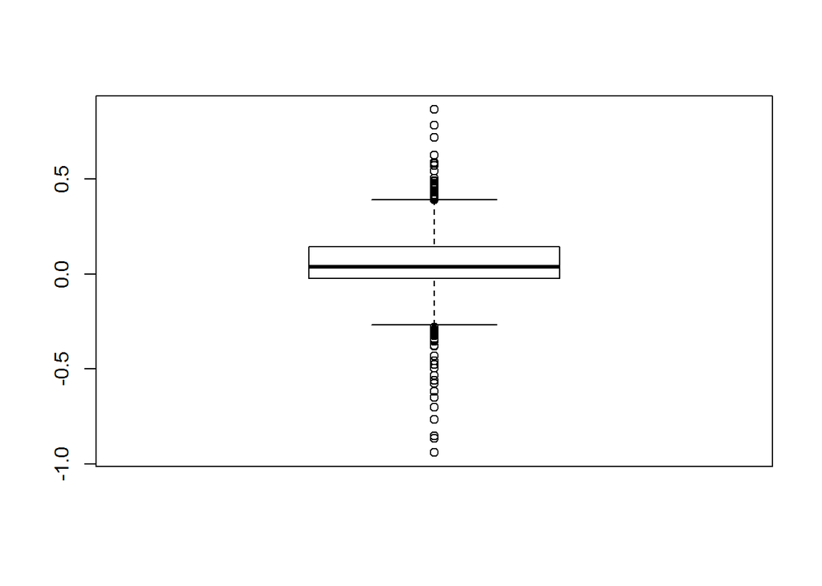

```r
#quick graphical examination of the distribution of discrepant scores
boxplot(CL[AllData$ACS_Total >= 100])
```

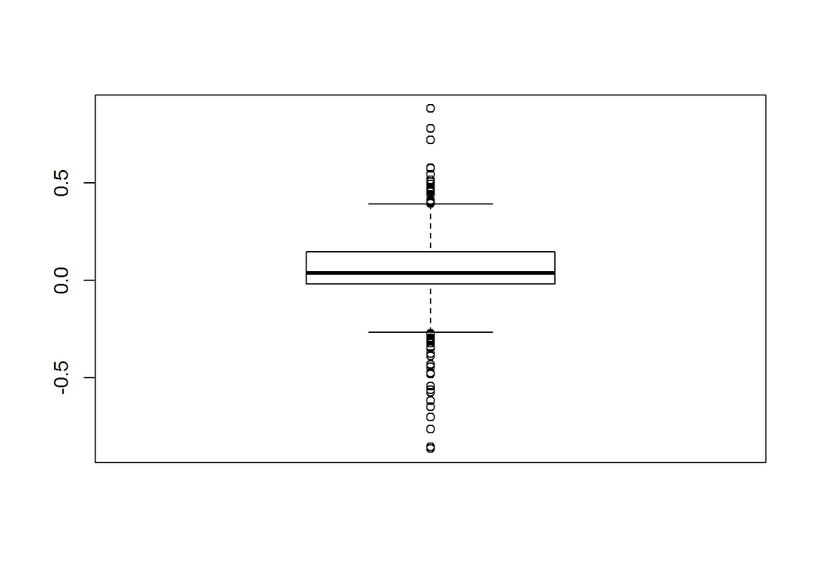

```r
boxplot(CH[AllData$ACS_Total >= 100])
```

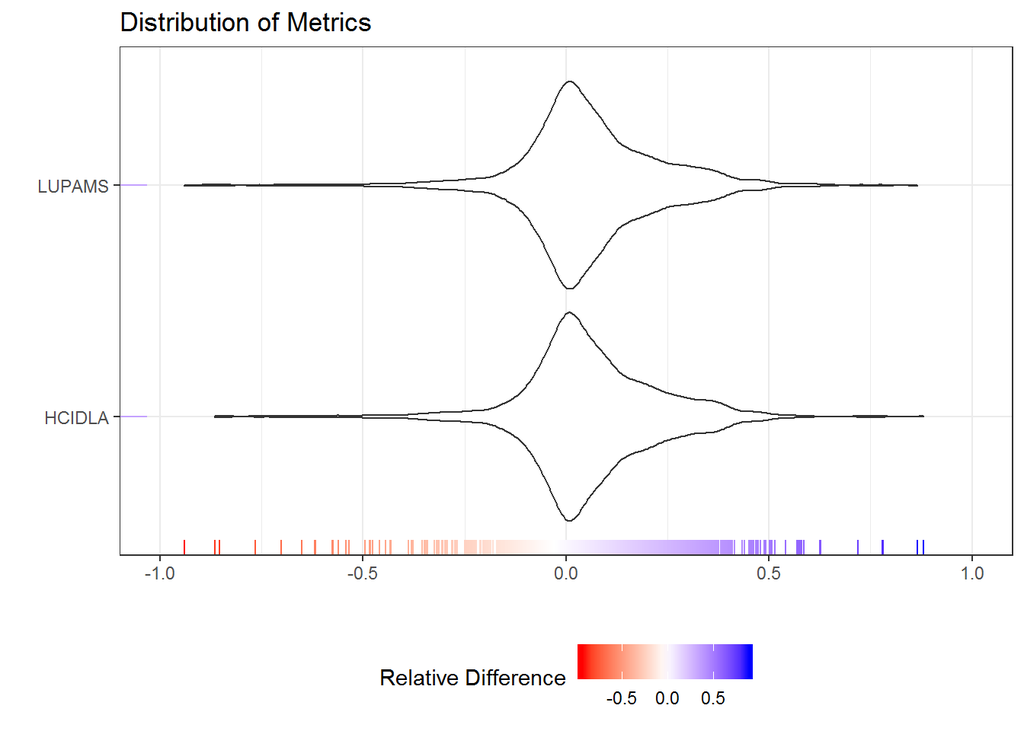

```r
#visualize this with a boxplot
CCL = cbind(CL[AllData$ACS_Total >= 100], "LUPAMS")
CCH = cbind(CH[AllData$ACS_Total >= 100], "HCIDLA")
CMetrics = data.frame(rbind(CCL, CCH))
names(CMetrics) = c("value","source")
CMetrics$value = as.numeric(as.character(CMetrics$value))

violin_plot = ggplot2::ggplot(data=CMetrics, aes(x=source, y=value, color=value)) +
  geom_violin() + coord_flip() + theme_bw() +
  scale_y_continuous(limits=c(-1,1)) +
  geom_rug() + scale_color_gradientn(colours=c("red","white", "blue"), na.value = NA) +
  theme(legend.position="bottom") +
  labs(title="Distribution of Metrics",x="",y="", color="Relative Difference")

box_plot = ggplot2::ggplot(data=CMetrics, aes(x=source, y=value, color=value)) +
  geom_boxplot(outlier.shape = 4) + coord_flip() + theme_bw() +
  scale_y_continuous(limits=c(-1,1)) +
  geom_rug() + scale_color_gradientn(colours=c("red","white", "blue"), na.value = NA) +
  theme(legend.position="bottom") +
  labs(title="Distribution of Metrics",x="",y="",color="Relative Difference")

(violin_plot)
```

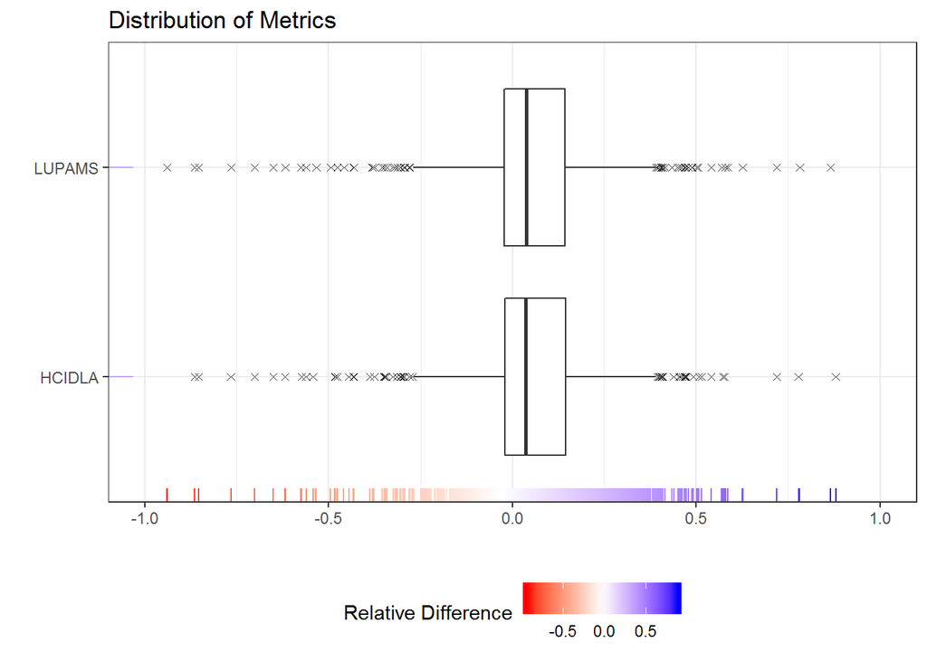

```r
(box_plot)
```

```r
CL = (AllData$LUPAMS-AllData$ACS_MFRENTALS)/AllData$ACS_Total

#...and similarly for HCID

CH = (AllData$HCIDLA-AllData$ACS_MFRENTALS)/AllData$ACS_Total



#adding these discrepancy scores to the data set

AllData = cbind(AllData, CL)
AllData = cbind(AllData, CH)
```

# Identification of “Discrepant” Areas

Areas with number closest to “0” essentially mean that the Census multi-family housing total is similar with the totals reported from the LA housing data sets. These areas are not considered: Instead we chose to examine the extreme areas where the Census count was over- or under-estimating total multi-family housing units by using the 1st quartile and 3rd quartile as cut-off scores, respectively. This step essentially reduces the data set from just under 1,000 to approximately 260 largely discrepant sections (130 sections under-estimated and 130 sections over-estimated) We subsetted out the largest discrepancies in LUPAMS first.

Above the 3rd quartile (i.e., areas where LUPAMS reported more multi-family units), were just over 250 observations, ranging from discrepant scores of .14310 - .86520.

We further split this up at the median discrepant value of these observations to create areas that were “moderately discrepant” vs. “severely discrepant.” For the remaining markdown description, only the severely discrepant analyses are presented, which ultimately consisted of 124 observations/areas identified as being severly discrepant, over ACS reporting values.

```r
over3rdCL <- AllData[AllData$CL > 0.14310,] #leaves 254 observations


severelyover <- over3rdCL[over3rdCL$CL > .2549,]  #leaves with 124 observations

#dropping infinity values from set
severelyover <- severelyover[-c(114, 123, 127:129),]
```

Similar steps were followed for scores below the 1st quartile of the total group, and subsequently below the median value of the 1st quartile only group.

This left us with *128* observation/areas identified as being severly discrepant, under ACS reporting values.

```r
under1stCL <- AllData[AllData$CL < -0.02207,]
summary(under1stCL$CL)
```

```
##     Min.  1st Qu.   Median     Mean  3rd Qu.     Max.     NA's
## -1.00000 -0.15607 -0.08166 -0.14403 -0.04960 -0.02208        4
```

```r
severelyunderCL <- under1stCL[under1stCL$CL < -0.08166,]
```

Similar steps were done with the HCID data set. Total observations and distributions indicated that both LUPAMS and HCID were reporting similar totals of multi-family units. Given this, we do not discuss the confirmed correlational analyses obtained with the HCID data to minimize redudancy of the report.

# Preliminary Correlations

With identified discrepant areas, we next examined correlations among ACS-ROI variables and discrepancies between ACS and LUPAMS for Multifamily households

Presented first are all available correlations are all/only for the *severely over* LUPAMS Estimated Group. Variables were supplied as being “people”-related (e.g., percent of college educated residents) or “place”-related (e.g., percentage of 9th graders who go on to graduate in the area). Variables that were education-place did not have variability in the score (i.e., were the same) and could not be included in analyses presented below.

```r
#People Variables

#Education related

CLSevOvEduPpl = cbind(severelyover[, names(severelyover) %in% c("CL", "edppl1", "edppl2", "edppl3", "edppl4")])
CLSevOvEduPpl[] = lapply(CLSevOvEduPpl, function(x) {if(is.factor(x)) as.numeric(as.character(x)) else x })
CorrCLOSevEduPpl <- ggpairs(CLSevOvEduPpl)


#Housing, Economic, and Civic Life related

CLSevOvEconHousePpl = cbind(severelyover[, names(severelyover) %in% c("CL", "ecppl1", "ecppl2", "hsppl1", "hsppl2", "soppl1", "soppl3")])
CLSevOvEconHousePpl[] = lapply(CLSevOvEconHousePpl, function(x) {if(is.factor(x)) as.numeric(as.character(x)) else x })
CorrCLOSevEcoPpl  <- ggpairs(CLSevOvEconHousePpl)


#Mobility and Health related

CLSevOvMobHeal = cbind(severelyover [, names(severelyover) %in% c("CL", "moppl1", "moppl2", "moppl3", "enppl1", "enppl2", "enppl3")])
CLSevOvMobHeal[] = lapply(CLSevOvMobHeal, function(x) {if(is.factor(x)) as.numeric(as.character(x)) else x })
CorrCLOSevMob <- ggpairs(CLSevOvMobHeal)



#Place data

#Economics related


CLSevOvEcoPlc = cbind(severelyover [, names(severelyover) %in% c("CL", "ecplc1", "ecplc2", "ecplc3", "ecplc4", "ecplc5")])
CLSevOvEcoPlc[] = lapply(CLSevOvEcoPlc, function(x) {if(is.factor(x)) as.numeric(as.character(x)) else x })
CorrCLOSevEcoplc <- ggpairs(CLSevOvEcoPlc)


#Housing, Health, Civic related

CLSevOvOthPlc = cbind(severelyover [, names(severelyover) %in% c("CL", "hsplc1", "hsplc2", "enplc1", "enplc2", "enplc3", "enplc4", "soplc1", "soplc2")])

CLSevOvOthPlc[] = lapply(CLSevOvOthPlc, function(x) {if(is.factor(x)) as.numeric(as.character(x)) else x })

CorrCLOSevOthplc <- ggpairs(CLSevOvOthPlc)



#General Resident Demographic related

CLSevOvCens = cbind(severelyover [, names(severelyover) %in% c("CL", "pct_un18", "pct_ov65", "pct_hisp", "pct_asian", "pct_black", "pct_white")])

CLSevOvCens[] = lapply(CLSevOvCens, function(x) {if(is.factor(x)) as.numeric(as.character(x)) else x })

CorrCLOSevCens <- ggpairs(CLSevOvCens)
```

An individual examination of each of the correlational objects indicated the top 8 correlations with the discrepant LUPAMS score in instances where the LUPAMS multi-family count was *greater* than the ACS count

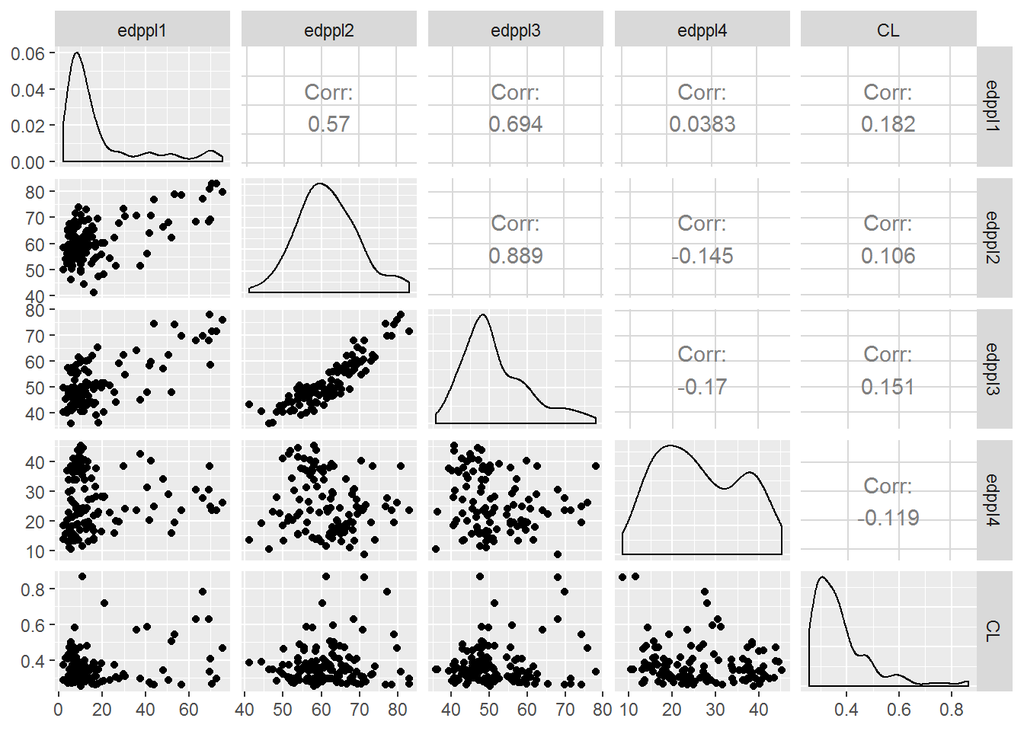

```r
CorrCLOSevEduPpl
```

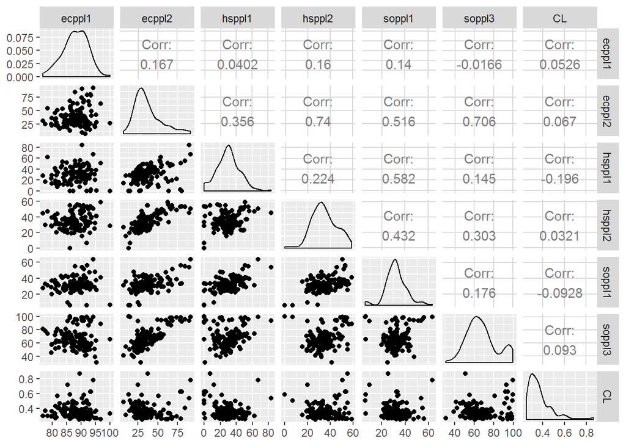

```r
CorrCLOSevEcoPpl
```

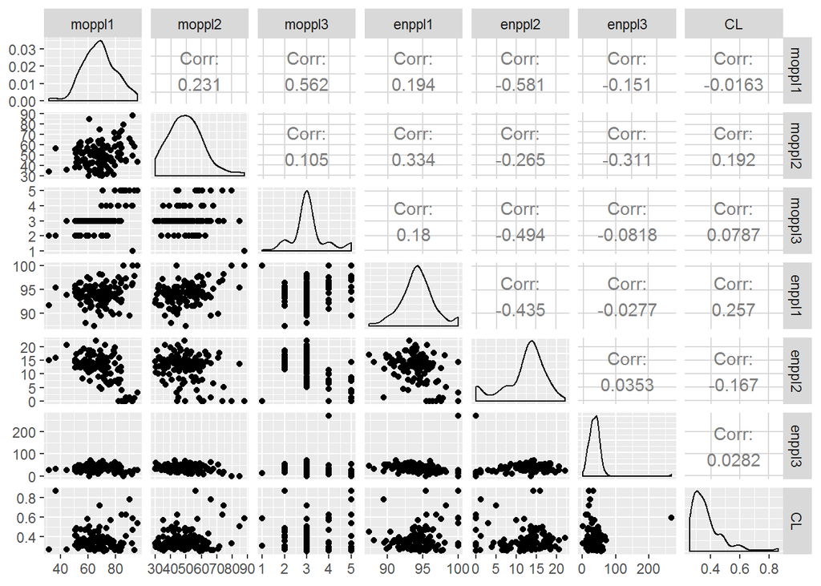

```r
CorrCLOSevMob
```

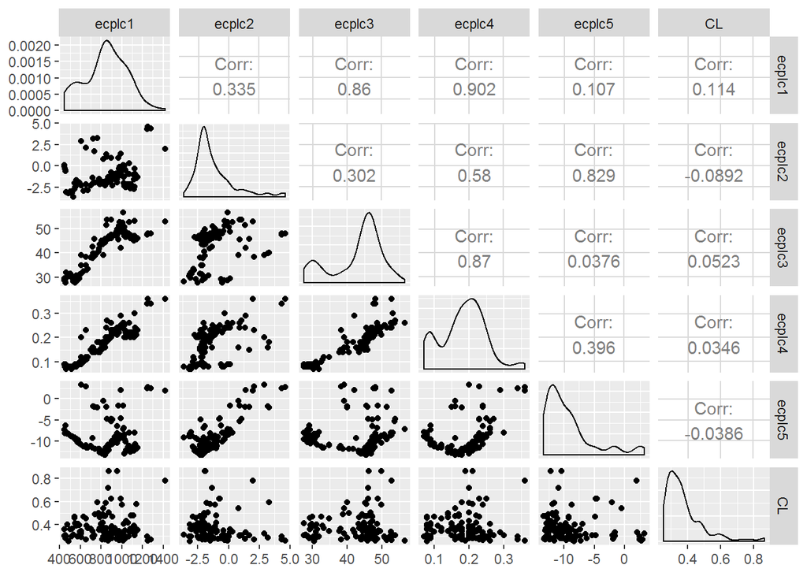

```r
CorrCLOSevEcoplc
```

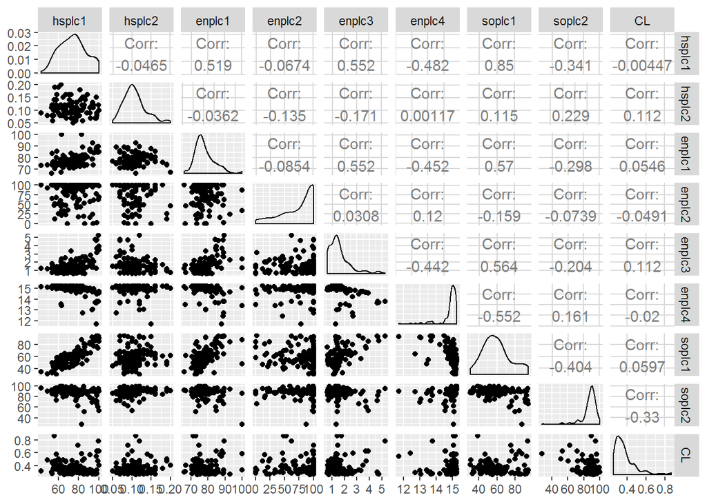

```r
CorrCLOSevOthplc
```

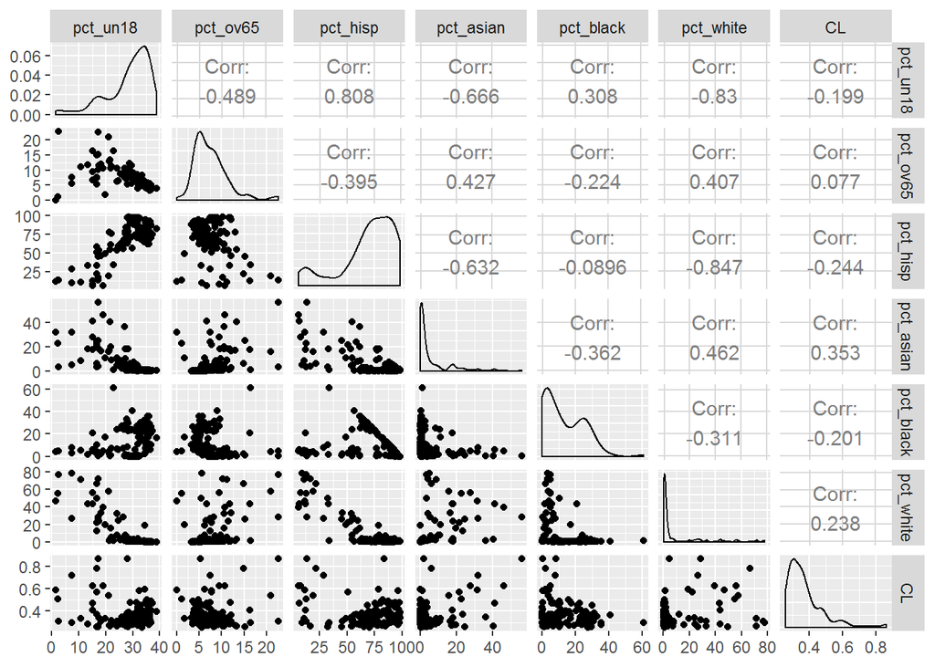

```r
CorrCLOSevCens
```

Next, similar steps were taken to examine ACS ROI variables with the LUPAMS discrepant group that was *severely under* the total reported by ACS.

```r
#People Variables

#Education related

CLSevUnEduPpl = cbind(severelyunderCL[, names(severelyunderCL) %in% c("CL", "edppl1", "edppl2", "edppl3", "edppl4")])
CLSevUnEduPpl[] = lapply(CLSevUnEduPpl, function(x) {if(is.factor(x)) as.numeric(as.character(x)) else x })
CorrCLUSevEduPpl <- ggpairs(CLSevUnEduPpl)


#Housing, Economic, and Civic Life related

CLSevUnEconHousePpl = cbind(severelyunderCL[, names(severelyunderCL) %in% c("CL", "ecppl1", "ecppl2", "hsppl1", "hsppl2", "soppl1", "soppl3")])
CLSevUnEconHousePpl[] = lapply(CLSevUnEconHousePpl, function(x) {if(is.factor(x)) as.numeric(as.character(x)) else x })
CorrCLUSevEcoPpl  <- ggpairs(CLSevUnEconHousePpl)


#Mobility and Health related

CLSevUnMobHeal = cbind(severelyunderCL [, names(severelyunderCL) %in% c("CL", "moppl1", "moppl2", "moppl3", "enppl1", "enppl2", "enppl3")])
CLSevUnMobHeal[] = lapply(CLSevUnMobHeal, function(x) {if(is.factor(x)) as.numeric(as.character(x)) else x })
CorrCLUSevMob <- ggpairs(CLSevUnMobHeal)


#Place variables


#Economics related


CLSevUnEcoPlc = cbind(severelyunderCL [, names(severelyunderCL) %in% c("CL", "ecplc1", "ecplc2", "ecplc3", "ecplc4", "ecplc5")])
CLSevUnEcoPlc[] = lapply(CLSevUnEcoPlc, function(x) {if(is.factor(x)) as.numeric(as.character(x)) else x })
CorrCLUSevEcoplc <- ggpairs(CLSevUnEcoPlc)


#Housing, Health and Civic related

CLSevUnOthPlc = cbind(severelyunderCL [, names(severelyunderCL) %in% c("CL", "hsplc1", "hsplc2", "enplc1", "enplc2", "enplc3", "enplc4", "soplc1", "soplc2")])
CLSevUnOthPlc[] = lapply(CLSevUnOthPlc, function(x) {if(is.factor(x)) as.numeric(as.character(x)) else x })
CorrCLUSevOthplc <- ggpairs(CLSevUnOthPlc)



#General Census data

CLSevUnCens = cbind(severelyunderCL [, names(severelyunderCL) %in% c("CL", "pct_un18", "pct_ov65", "pct_hisp", "pct_asian", "pct_black", "pct_white")])
CLSevUnCens[] = lapply(CLSevUnCens, function(x) {if(is.factor(x)) as.numeric(as.character(x)) else x })
CorrCLUSevCens <- ggpairs(CLSevUnCens)
```

An individual examination of each of the correlational objects indicated the top 8 correlations with the discrepant LUPAMS score in instances where the LUPAMS multi-family count was *lesser* than the ACS count

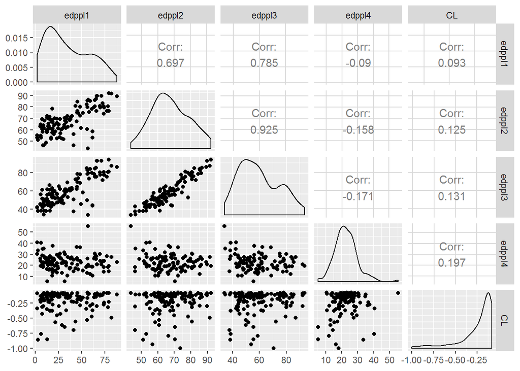

```r
CorrCLUSevEduPpl
```

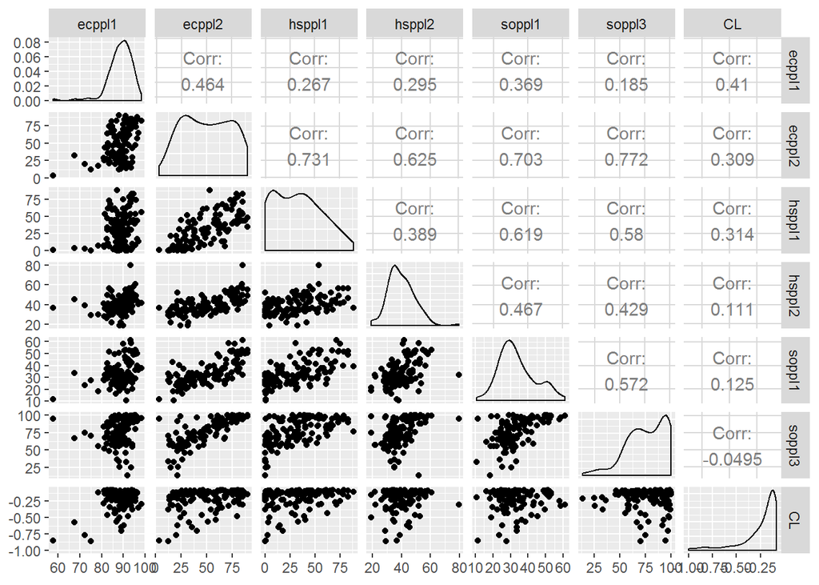

```r
CorrCLUSevEcoPpl
```

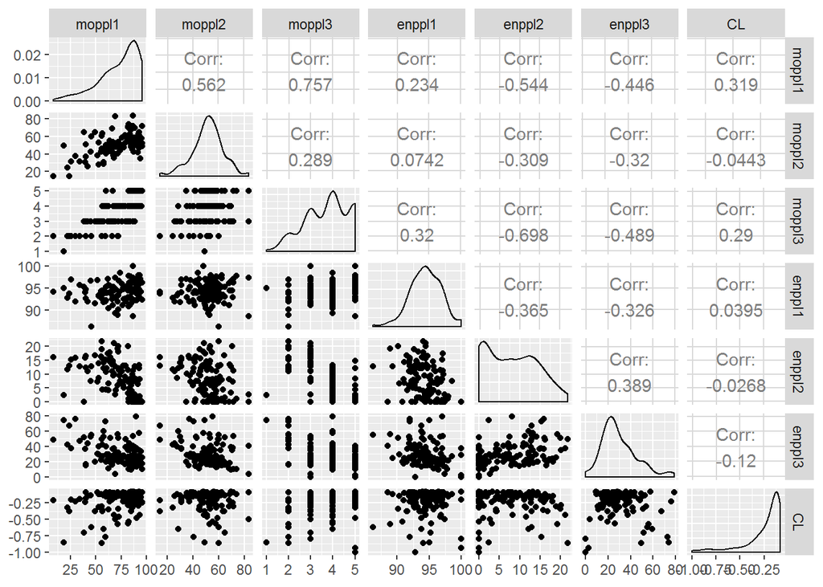

```r
CorrCLUSevMob
```

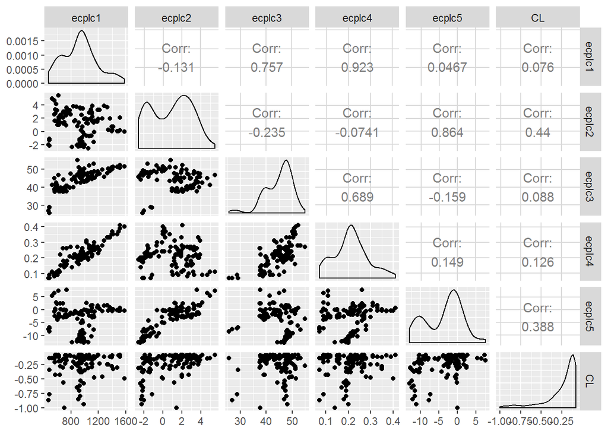

```r
CorrCLUSevEcoplc
```

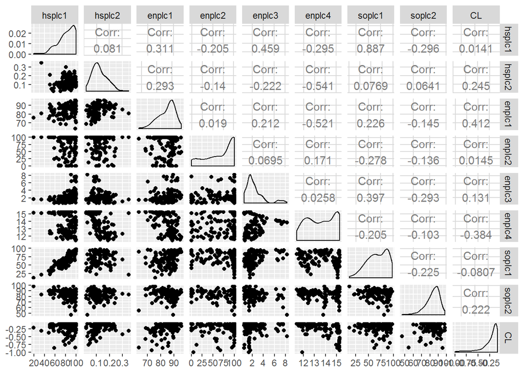

```r
CorrCLUSevOthplc
```

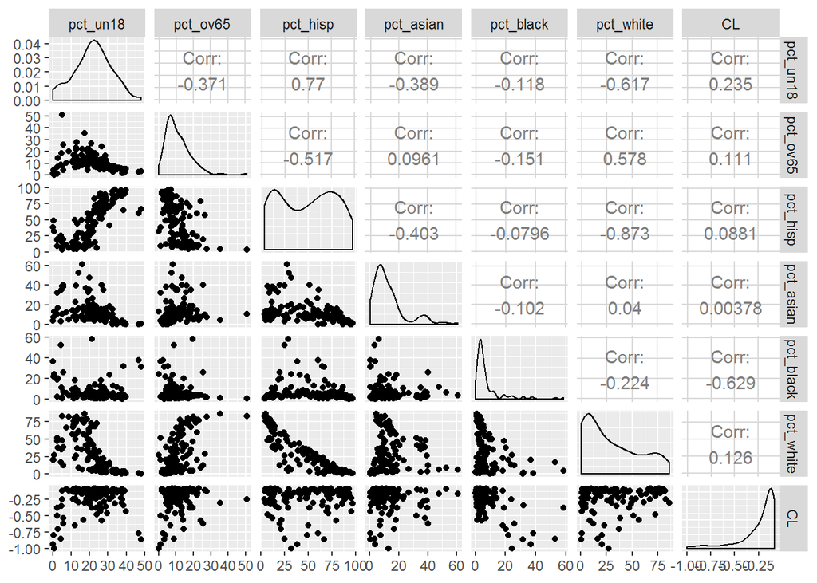

```r
CorrCLUSevCens
```

# Graphing Correlations of Interest

## Severely Under Correlations

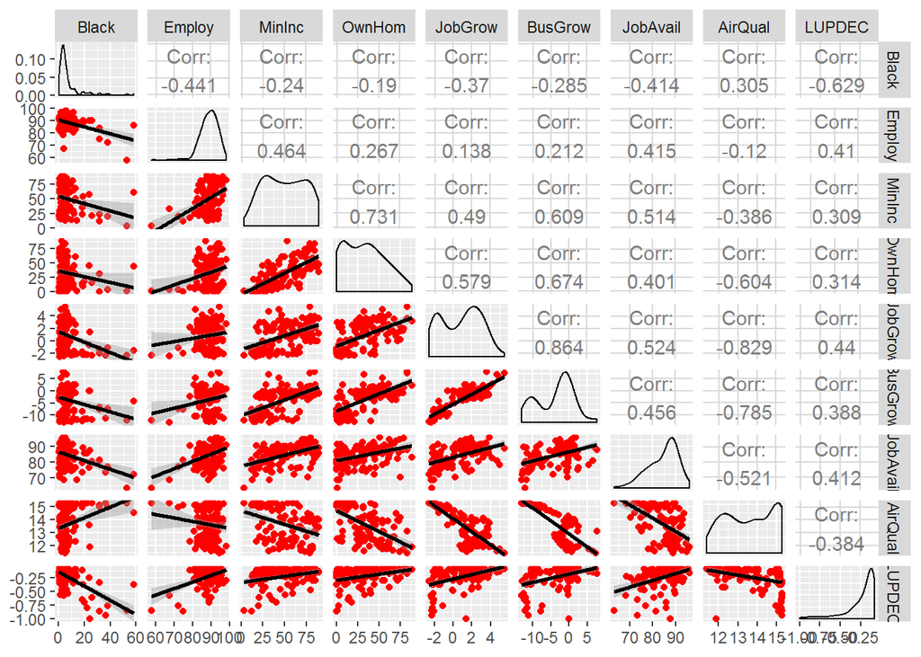

```r
UnderCorrSet = cbind(severelyunderCL[, names(severelyunderCL) %in% c("CL", "pct_black", "ecppl1", "ecppl2", "hsppl1", "ecplc2", "ecplc5", "enplc1", "enplc4")])



#added specific names to assist in interpretation

colnames(UnderCorrSet) <- c("Black", "Employ", "MinInc", "OwnHom", "JobGrow", "BusGrow", "JobAvail", "AirQual", "LUPDEC")

UnderCorrSet[] = lapply(UnderCorrSet, function(x) {if(is.factor(x)) as.numeric(as.character(x)) else x })

#added color and linear regression line to each scatter plot

UnderCorrGraph <- ggpairs(UnderCorrSet,
                          lower = list(continuous = wrap("smooth", colour = "red")))


UnderCorrGraph
```

## Severely Under Additional

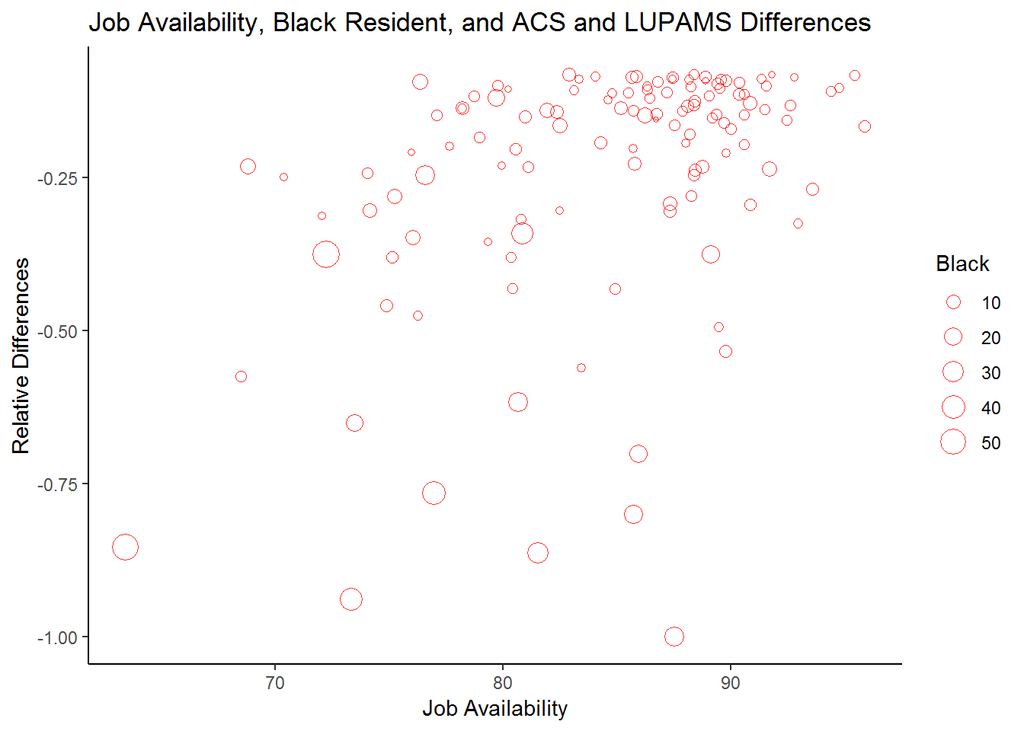

```r
Underbubble <- ggplot(UnderCorrSet, aes(x = JobAvail, y = LUPDEC, size = Black)) +
  geom_point(shape = 21, color = "red", alpha = .8) +
   labs(title = "Job Availability, Black Resident, and ACS and LUPAMS Differences", x = "Job Availability", y = "Relative Differences") +
             theme(plot.title =element_text(size = 16, face = "bold", hjust = 1),
              axis.text.x = element_text(size = 5),
              axis.text.y = element_text(size = 5),
              axis.title.x = element_text(size = 8),
              axis.title.y = element_text(size = 8)) +
             theme_classic()

Underbubble
```

## Severely Over Correlations

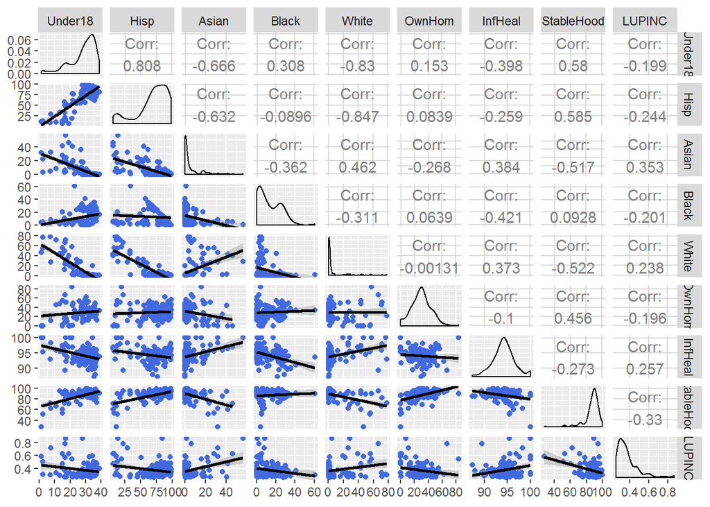

```r
OverCorrSet = cbind(severelyover[, names(severelyover) %in% c("CL", "pct_un18", "pct_hisp", "pct_asian", "pct_black", "pct_white", "soplc2", "hsppl1", "enppl1")])

colnames(OverCorrSet) <- c("Under18", "Hisp", "Asian", "Black", "White", "OwnHom", "InfHeal", "StableHood", "LUPINC")
OverCorrSet[] = lapply(OverCorrSet, function(x) {if(is.factor(x)) as.numeric(as.character(x)) else x })
OverCorrGraph <- ggpairs(OverCorrSet, lower = list(continuous = wrap("smooth", colour = "royalblue")))

OverCorrGraph
```

## Severely Over Additional

Additional graphical exploration plotted the two highest correlation values (i.e., percentage of asian residents and neighborhood stability in the area) with the LUPAMS discrepant values

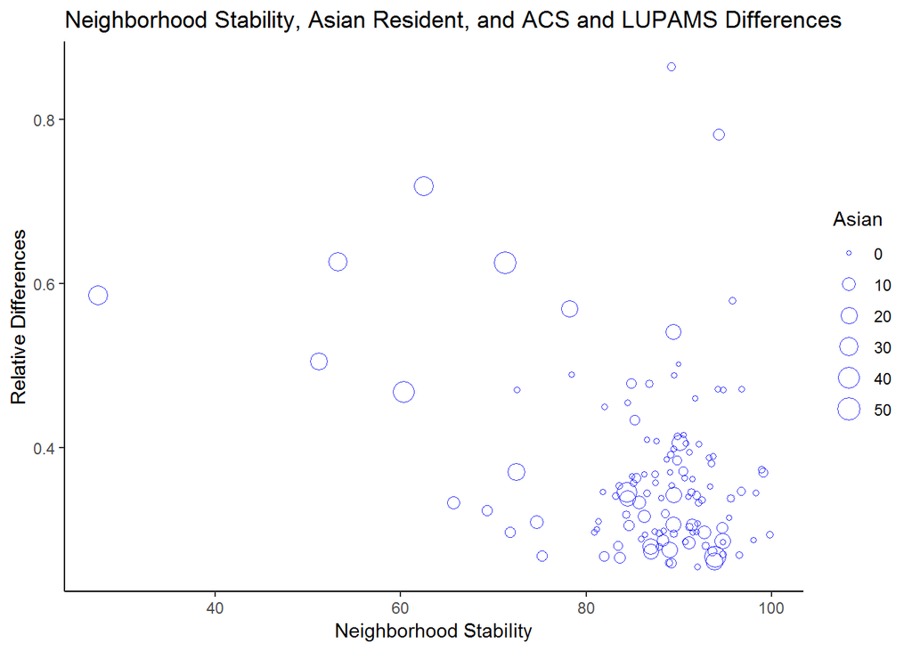

```r
Overbubble <- ggplot(OverCorrSet,
                     aes(x = StableHood, y = LUPINC, size = Asian)) +
  geom_point(shape = 21, color = "blue", alpha = .8) +
   labs(title = "Neighborhood Stability, Asian Resident, and ACS and LUPAMS Differences",
        x = "Neighborhood Stability", y = "Relative Differences") +
             theme(plot.title =element_text(size = 14, face = "bold"),
              axis.text.x = element_text(size = 5),
              axis.text.y = element_text(size = 5),
              axis.title.x = element_text(size = 8),
              axis.title.y = element_text(size = 8)) +
             theme_classic()

Overbubble
```

# Mapping Discrepancies

Here we create maps of the data, color-coded for our metric, with and without overlays of GGmap data:

```r
#downloaded the tract geometry info from
# https://www.census.gov/geo/maps-data/data/cbf/cbf_tracts.html

tract <- readOGR(dsn=".", layer = "cb_2015_06_tract_500k")
#pulled these two lines from a help file online
tract@data$GEOID<-as.character(tract@data$GEOID)
ggtract<-fortify(tract, region = "GEOID")

names(ggtract)[6] = "GEOID"
ggtract$GEOID = as.numeric(ggtract$GEOID)

#restrict tract data to just the LA area
ggtract_LA = ggtract[ggtract$GEOID %in% CensusData$GEOID,]

#trim out areas with less than 100 households
CL[AllData$ACS_Total < 100] = NA
CH[AllData$ACS_Total < 100] = NA

housing_metrics = data.frame(cbind(AllData$GEOID,CL,CH))
names(housing_metrics)[1] = "GEOID"

#don't want the merge to re-order the geometry
ggtract_LA$order = 1:nrow(ggtract_LA)
all_LA_Data = merge(ggtract_LA, housing_metrics)
all_LA_Data = all_LA_Data[order(all_LA_Data$order),]
```

```r
ditch_the_axes = theme(
  axis.text = element_blank(),
  axis.line = element_blank(),
  axis.ticks = element_blank(),
  panel.border = element_blank(),
  panel.grid = element_blank(),
  axis.title = element_blank(),
  panel.background = element_blank()
)
```

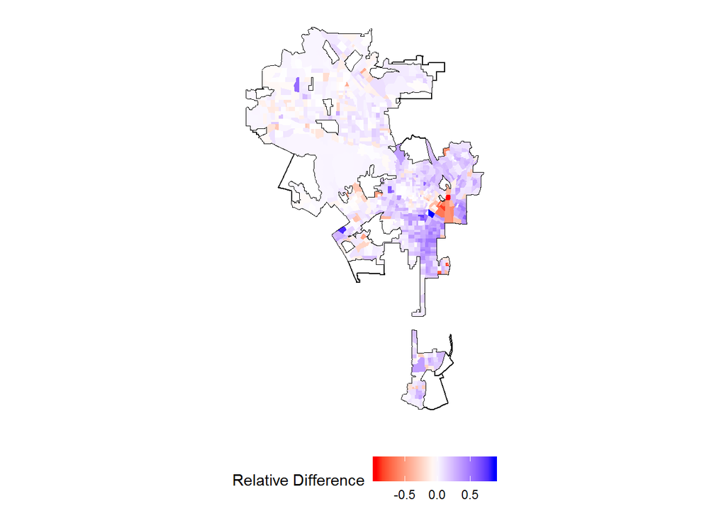

```r
ca_base = ggplot(data = ggtract_LA, mapping = aes(x = long, y = lat, group = group), color="black") +
  coord_fixed(1.3) +
  geom_polygon(color = "black", fill = NA) +
  labs(fill="Relative Difference") +
  theme(legend.position="bottom") +
  ditch_the_axes

LA_with_colors = ca_base +
  geom_polygon(data = all_LA_Data, aes(fill = CH)) +
  scale_fill_gradientn(colours=c("red","white", "blue"), na.value = NA)



LA_with_colors = ca_base +
  geom_polygon(data = all_LA_Data, aes(fill = CL)) +
  scale_fill_gradientn(colours=c("red","white", "blue"), na.value = NA)



LA_with_colors
```

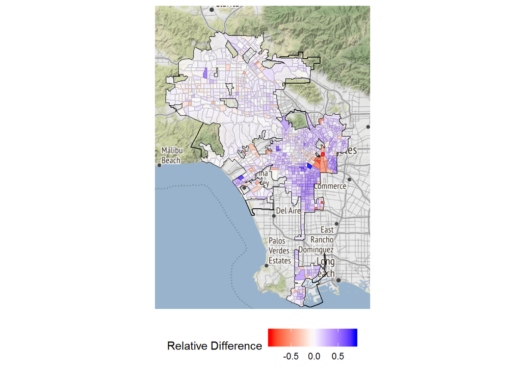

```r
LA_map = ggmap(get_map(location= c(-118.7,33.7,-118.1,34.4), zoom = 10, maptype="roadmap"))

alpha = 0.8

LA_with_colors = LA_map +
  geom_polygon(data = ggtract_LA, aes(x=long,y=lat, group=group),
               color = "black", alpha = alpha, fill = NA) +
  geom_polygon(data = all_LA_Data, aes(x=long,y=lat, group =group, fill = CH),alpha = alpha) +
  scale_fill_gradientn(colours=c("red","white", "blue"),
                       na.value = NA) +
  labs(fill="Relative Difference") +
  theme(legend.position="bottom") +
  ditch_the_axes



LA_with_colors = LA_map +
  geom_polygon(data = ggtract_LA, aes(x=long,y=lat, group=group),
               color = "black", alpha = alpha, fill = NA) +
  geom_polygon(data = all_LA_Data, aes(x=long,y=lat, group =group, fill = CL),alpha = alpha) +
  scale_fill_gradientn(colours=c("red","white", "blue"),
                       na.value = NA) +
  labs(fill="Relative Difference") +
  theme(legend.position="bottom") +
  ditch_the_axes



LA_with_colors
```